# Rodents

[NO_RODE_001]

Author

Affiliation

Anders Kolstad

The Norwegian Institute for Nature Research (NINA)

Published

July 3, 2026

Reviewed by

Matthew Grainger

> **Recommended citation**: Kolstad, A. 2026. Rodents [Smågnagere] (ID(s): NO_RODE_001) v. 1.0.0. ecRxiv: https://github.com/NINAnor/ecRxiv/tree/main/indicators/NO_RODE_001

**Metadata**

Table 1: Indicator metadata

| Variable | Value |
| --- | --- |
| Indicator ID | NO_RODE_001 |
| Indicator Name | Rodents [Smågnagere] |
| verbatimName | Smågnagere |
| Country | Norway |
| Continent | Europe |
| Ecosystem Condition Typology Class | B3 - Functional state characteristics |
| Realm | Terrestrial (T) |
| Biome | T6 Polar-alpine (cryogenic) biome |
| Ecosystem | NA |
| verbatimEcosystem | Fjell |
| Year added | 2026 |
| Last update | 2026 |
| Version | 1.0.0 |
| Version comment | First version on ecRxiv, but this indicator is already published and described in the Norwegian Nature Index |
| Normalised | TRUE |
| Spatial aggregation pathway | [Scale - truncate] - Dis-aggregate (municipalities) - Aggregate (geographic regions) - Aggregate (Norway) |

**Log**

- May 28, 2026 - Started work
- July 3, 2026 - Accepted

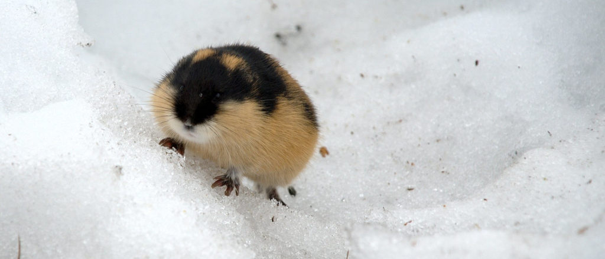

Figure 1: Lemming. Photo: kgleditsch, CC BY-SA 2.0, via Wikimedia Commons.

```r
knitr::include_graphics(here::here("img/Lemming_in_snow.png"))
```

## 1. Summary

1. **Background and rationale**: Small rodents, such as lemmings and mice, are keystone species in alpine ecosystems. They function as a trophic link between the primary producers and top predators. When population are high, they impose a large disturbance on the vegetation, but at the same time they fuel the higher trophic levels and ensure survival and breeding success for species like raptors and foxes. Rodent cycles have a frequency of about 3-4 years, and it is the amplitude (size or height) of these peaks that make up this indicator. Rodent cycles, both their regularity and their amplitude, are negatively affected by many known and unknown drivers. The most important anthropogenic driver is climate change, with warmer and wetter winters causing rodent declines due to the effect that this has on the snow cover.
2. **Methods**: Rodent numbers have been monitored from 1990 to 2020 using traps. A new national monitoring program was initiated in 2020 based on camera traps, but these data are not yet integrated with the existing time series, so the 2024 estimate is based on expert opinion, informed by various data sources.  
   We get the data from the Norwegian Nature Index database (Nater and Eriksen 2025) where also the X<sub>100</sub> reference values are stored. These represent the predicted mean number of rodents in peaks year over a 10 year period, given minimal anthropogenic influence. The reference values are also based on expert opinion, but informed by extensive empirical data.
3. **Interpretation**: An indicator value of 1 means that rodent numbers in peak years are as numerous, or more than what we expect under the reference condition. Values decreasing toward zero indicates that the average rodent peaks are diminishing.
4. **Results and development needs**: The indicator value for Norway as a whole in 2024 was 0.28 [95% CI = 0.26-0.30]. This is extremely low and reflects the deminishing effect of rodent cycles on Norwegian alpine ecosystems. Development needs include an integration of the current monitoring time series, with the old time series based on trap monitoring.

## 1.2 Native language summary - Norwegian

1. **Bakgrunn og begrunnelse**: Smågnagere, som lemen og mus, er nøkkelarter i alpine økosystemer. De fungerer som et trofisk bindeledd mellom primærprodusenter og toppredatorer. Når bestandene er høye, påfører de vegetasjonen betydelige forstyrrelser, men samtidig opprettholdes de høyere trofiske nivåene og smågnagerne sikrer overlevelse og hekkesuksess for arter som rovfugler og rever. Smågnagersyklusene har en frekvens på omtrent 3–4 år, og det er amplituden (størrelsen eller høyden) på toppårene som utgjør denne indikatoren. Smågnagersyklusene, både regelmessigheten og amplituden, påvirkes negativt av mange kjente og ukjente faktorer. Den viktigste menneskeskapte påvirkningsfaktoren er klimaendringer, der varmere og våtere vintre fører til nedgang i smågnagerbestandene på grunn av effektene dette har på snødekket.
2. **Metoder**: Smågnagerbestander har blitt overvåket fra 1990 til 2020 ved hjelp av feller. Et nytt nasjonalt overvåkingsprogram ble startet i 2020 basert på kamerafeller, men disse dataene er ennå ikke integrert med de eksisterende tidsseriene. Estimatet for 2024 er derfor basert på ekspertvurderinger informert av ulike datakilder. Dataene hentes fra databasen for Naturindeks for Norge (Nater and Eriksen 2025), hvor også referanseverdiene X<sub>100</sub> er lagret. Disse representerer det forventede gjennomsnittlige antallet smågnagere i toppår over en 10-årsperiode under minimale menneskeskapte påvirkninger. Referanseverdiene er også basert på ekspertvurderinger, men støttes av omfattende empiriske data.
3. **Tolkning**: En indikatorverdi på 1 betyr at smågnagerbestandene i toppår er like store, eller større, enn det vi forventer under referansetilstanden. Verdier som nærmer seg null indikerer at toppene i smågnagersyklusene blir svakere.
4. **Resultater og utviklingsbehov**: Indikatorverdien for hele Norge i 2024 er 0,28 [95 % KI = 0,26–0,30]. Dette er svært lavt og gjenspeiler den reduserte effekten smågnagersyklusene har på norske alpine økosystemer. Utviklingsbehov inkluderer integrering av de nåværende overvåkingsseriene med de eldre tidsseriene basert på felleovervåking.

## 2. About the underlying data

The data comes from various trap monitoring time series, especially TOV (Framstad 2017) and selected time series from (Ehrich et al. 2020). The 2024 estimate is based on expert opinion (Nater and Eriksen 2025) . See further documentation on the [Norwegian Nature Index web site for this indicator](https://www.naturindeks.no/Indicators/smaagnagere_fjellbestander).

### 2.1 Spatial and temporal resolution and extent

Indicator values are available for the different assessment years in *Naturindeksen*: 1950 (expert opinion-based estimate), 1990, 2000, 2010, 2014, 2019 and 2024 (also expert opinion-based).

### 2.2 Sampling design

When empirical data is used, these are mostly from trap monitoring time series. Some qualitative data sources are used as well. See more information on the [Naturindeks web site](https://www.naturindeks.no/Indicators/smaagnagere_fjellbestander) and the workflow documentation found [here](https://naturindeks.nina.no/docs/ae75dc3a-2152-4365-8944-cc1d6e7a7f03.pdf).

### 2.3 Original units

The original units of the raw data is *the average size of population peaks over a 10 year period, measured as captured per 100 capture-days*.

### 2.4 Instructions for citing, using and accessing data

Indicator values from the Norwegian Nature Index can be found in (Nater et al. 2025). Indicator values, variable values and reference values can be downloaded from the Nature Index database using the API, as I have done below. The data is licenced under [CC-BY 4.0](https://creativecommons.org/licenses/by/4.0/).

## 3. Indicator properties

### 3.1 Ecosystem Condition Typology Class (ECT)

B3 - Functional state characteristics

### 3.2 Ecosystem condition characteristic

The ecosystem characteristic represented in this indicator is an ecosystem where ecosystem functions are stable (or at least predictable) and intact, and where tropic interactions occur as they would uder the reference condition.

### 3.3 Collinearities with other indicators

Since rodents are functional links between so many species and trophic levels, it is assumed to be a strongly correlated to several other indicator, such as a potential snow depth indicator, and the arctic fox indicator (NO_AFOX_001).

### 3.4 Impact factors

Alpine rodents are influced by both natural (known and unknown) factors, such as predation, as well as antropogenic drivers, of which climate change is the most important. Wetter and warmer winters cause the snow cover to become thinner, less stable and less insulation, which negatively affects survival and fitness in general.

### 3.5 Spatial aggregation

## 4. Reference condition and levels

### 4.1 Reference condition

The reference condition is a mountain ecosystem with minimal human impact and a climate similar to the period 1961-1990 (Nybø and Evju (red) 2017).

### 4.2 Reference levels

X<sub>100</sub> is defined based on the predicted size of rodent peaks. It is quantified from expert opinion, but informed from empirical data.

X<sub>0</sub> is defined as a complete absence of rodents.

#### 4.2.1 Spatial resolution and validity

The reference values vary between 10 regions in Norway.

## 5. Uncertainties

### 5.1 General uncertainties

One main source of uncertainty arises from the discontinuous time series, since the monitoring switched from trap minitoring to camera monitoring in 2020. There is also an issue with low spatial representation in the data pre 2020.

### 5.2 Reported uncertainties

The reported uncertainties reflect the uncertainties around the true parameter means, i.e. they are inferrential uncertainties for the true value of the indicator for the given area and time combination.

## 6. References

Ehrich, D., N. M. Schmidt, G. Gauthier, R. Alisauskas, A. Angerbjörn, K. Clark, F. Ecke, N. E. Eide, et al. 2020. Documenting lemming population change in the arctic: Can we detect trends? *Ambio* 49. Springer: 786–800.

Framstad, E. 2017. *Terrestrisk naturovervåking i 2016: Markvegetasjon, epifytter, smågnagere og fugl. Sammenfatning av resultater*. NINA Rapport 1376. Edited by Erik Framstad. Norsk institutt for naturforskning (NINA).

Nater, C. R., and L. F. Eriksen. 2025. *Naturindeks for Norge 2025. Tilstand og utvikling for biologisk mangfold.* {NINA} {Temahefte} 97. Trondheim: Norsk Institutt for Naturforskning.

Nater, C. R., T. Zeiner-Henriksen, and S. Nybø. 2025. NI2025: Indicator Data. doi:10.21345/y790-v762.

Nybø, S., and M. Evju (red). 2017. *[Fagsystem for fastsetting av god økologisk tilstand - forslag fra et ekspertråd](https://www.regjeringen.no/no/dokumenter/fagsystem-for-fastsetting-av-god-okologisk-tilstand/id2558481/)*.

## 7. Import and prepare datasets

### 7.1 Naturindeks

We download the dataset from the Naturindeks database using the API. The function gives read-only access without requiring a username and password.

```r
# I use a dev version of NIcalc where the username and passwork for the guest user is hrd coded into the function. This will probably be merged into the real NIcalc (from NINAnor/NIcalc) soon.
# renv::install("ChloeRN/NIcalc@include_ReadOnly_access")
# library(NIcalc)

#myYears <- as.character(c(1990, 2020, 2010, 2014, 2019, 2024))

# Import data set
roedImport <- NIcalc::importDatasetApi(
  eco = NULL,
  indic = c("Smågnagere - fjellbestander"),
  year = c("2010", "2014", "2019", "2024")
)
saveRDS(roedImport, here::here("data/roedImport.rds"))
```

## 8. Spatial units

According to the Naturindeks terminology, the 430 municipalities are called `BSunits`. In the current dataset, only 163 mountain municipalities are included.

The indicator data is available at the scale of 10 `ICunits`. These are combinations of municipalities and/or counties.

The five geographic regions in Norway (east, south, west, central, north) are called `parts` and `NIunits`. We can think of the `ICuntis` as ecosystem assets, and mainland Norway as the Ecosystem accounting Area.

## 9. Analyses

Here I use a generic approach to handling data from the Naturindeks where I get both the variable values and the reference values, separately, from the NI database, and perform the normalisation and spatial aggregation ourselves.

The reference values have uncertainties attached to them, which we will ignore here. The variable values have uncertainties as well, in the form of probability function. The uncertainties are from a statistical model, and so we think of them as inferential uncertainties.

Here I use an NIcalc function to just prepare and structure the data a little differently.

```r
# Assemble
assemble <- NIcalc::assembleNiObject(
  inputData = roedImport,
  predefNIunits = c(allArea = T, parts = T, counties = F),
  indexType = "thematic"
)
```

Then I get the reference values. These are unique to each ´ICunit`. I only have an X<sub>100</sub> value. X<sub>0</sub> is a natural zero.

```r
x100 <- roedImport$referenceValues$referenceValues |>
  select(ICunitId, ICunitName, x100 = expectedValue)
gt::gt(x100)
```

| ICunitId | ICunitName | x100 |
| --- | --- | --- |
| 5458 | Hedmark | 10 |
| 5459 | Oppland | 15 |
| 5460 | Buskerud, Telemark | 20 |
| 5461 | Agder, Rogaland | 20 |
| 5462 | Hordaland | 20 |
| 5463 | Sogn og Fjordane - Møre | 15 |
| 5465 | Midt-Norge, nord | 15 |
| 5466 | Midt-Norge, sør | 15 |
| 5467 | Nordland-Troms | 20 |
| 5468 | Nord-Troms, Finnmark | 20 |

The variable values are stored as a parameterised probability function, and I need to draw *n* samples from this function. The probability function differs between indicators in the Naturindeks. It could also differ within an indicator. Here I create a vector defining which probability function to use. I use ´tradObs´ where there is a regular probability distribution family, and `customObs` where customDist!= NA. When `distributionFamilyName == NA`, `customDistribution != NA`.

```r
myYears <- as.character(c(2010, 2014, 2019, 2024))

obstype <- NULL

for (i in 1:length(myYears)) {
  obs <- assemble$indicatorValues[[i]]$distributionFamilyName

  obs[!is.na(obs)] <- "tradObs"
  obs[is.na(obs)] <- "customObs"

  obstype[[i]] <- obs
}
```

Now I am ready to sample the probability distributions. I set *n* to be 1000.

```r
dat <- tibble(ICunitId = NULL, value = NULL, year = NULL)

for (i in 1:length(myYears)) {
  #print(i)
  myMat <- NIcalc::sampleObsMat(
    ICunitId = assemble$indicatorValues[[i]]$ICunitId,
    value = assemble$indicatorValues[[i]]$expectedValue,
    distrib = assemble$indicatorValues[[i]]$distributionFamilyName,
    mu = assemble$indicatorValues[[i]]$distParameter1,
    sig = assemble$indicatorValues[[i]]$distParameter2,
    customDistribution = assemble$indicatorValues[[i]]$customDistribution,
    obsType = obstype[[i]],
    nsim = 1000
  )
  ICunitIds <- row.names(myMat)

  myMat <-  myMat |>
    as_tibble() |>
    add_column(ICunitId = ICunitIds, .before = 1) |>
    pivot_longer(cols = -any_of("ICunitId")) |>
    select(-name) |>
    add_column(year = myYears[i])

  dat <- dat |>
    bind_rows(myMat)
}
head(dat)
```

```
# A tibble: 6 × 3
  ICunitId value year
  <chr>    <dbl> <chr>
1 5458     0.309 2010
2 5458     1.64  2010
3 5458     2.04  2010
4 5458     3.41  2010
5 5458     2.69  2010
6 5458     2.23  2010
```

This is the point in the spatial aggregation where we should normalise against the reference values. So let’s add inn the X<sub>100</sub> values.

```r
dat <- dat |>
  left_join(x100 |> mutate(ICunitId = as.character(ICunitId)), by = join_by(ICunitId))
```

Then we can normalise also the scatter plot with variables against indicator values (Figure 2).

```r
ind <- ec_normalise(
  variable = dat$value,
  x100 = dat$x100
)

dat <- dat |> add_column(indicator = ind)
```

```r
myMax <- max(dat$x100)
temp <- ec_norm_plot(dat$value, dat$indicator) +
  labs(x = "Avg. peak size") +
  xlim(c(0,myMax))

ggsave(here::here("img/norm_plot_eng_roed.png"), scale =1.5, plot =temp)
```

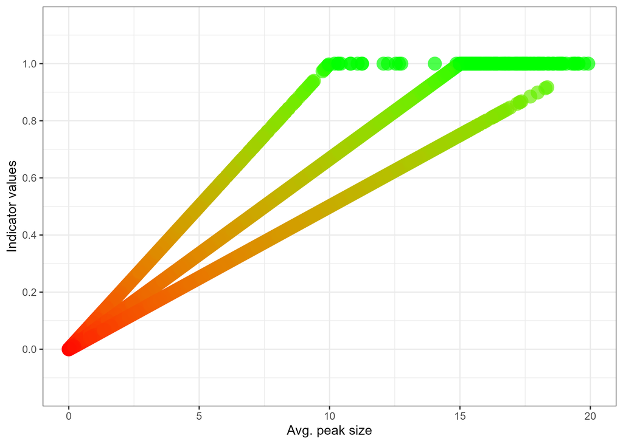

Figure 2: Normalisation (scaling and truncation) of variable values into indicator values. The X100 value differs between 10 regions in Norway. There are three unique X100 values, (10, 15 and 20); hance the three lines.

```r
knitr::include_graphics(here::here("img/norm_plot_eng_roed.png"))
```

I also export a figure for the Norwegian fact sheet:

**Export normalisation function plots**

```r
temp <- ec_norm_plot(dat$value, dat$indicator, lan = "norsk") +
  labs(x = "Størrelse på bestandstopper", y = "Indikatorverdi") +
  xlim(c(0, myMax))
ggsave(here::here("img/norm_plot_facet_roed.png"), scale =1.5, plot =temp)
```

### Prepare for aggregation

Then we estimate values for each geographic region (N, M, E, S, W). In *Naturindeks* this is done behind the scenes, and I’m not sure how.

I will downscale the indicator values from `ICunits` to `BSunits`. This is because these are not perfectly netsed. ICunit 5461 for example, contains Rogaland and Agder, but these belong to different `NIunits`. Based on the alpine area of each BSunit, I will upscale from BSunits to NIunits.

```r
# The link between BSunits and NIunits can be found here:
bs_ni <- as.data.frame(assemble$NIunits) |>
  rownames_to_column(var = "BSunits")
head(bs_ni)
```

```
      BSunits wholeArea E S W C N
1       Hamar         1 1 0 0 0 0
2   Ringsaker         1 1 0 0 0 0
3      Trysil         1 1 0 0 0 0
4        Åmot         1 1 0 0 0 0
5 Stor-Elvdal         1 1 0 0 0 0
6    Rendalen         1 1 0 0 0 0
```

```r
# And the link between BSunits and ICunits can be found here:
bs_ic <- as.data.frame(assemble$ICunits) |>
  rownames_to_column(var = "BSunits") |>
  rename(ICunits = "Smågnagere - fjellbestander")
head(bs_ic)
```

```
      BSunits ICunits
1       Hamar    5458
2   Ringsaker    5458
3      Trysil    5458
4        Åmot    5458
5 Stor-Elvdal    5458
6    Rendalen    5458
```

```r
# and then I combine them
bs_ni_ic <- bs_ni |>
  left_join(bs_ic, by = join_by(BSunits))
head(bs_ni_ic)
```

```
      BSunits wholeArea E S W C N ICunits
1       Hamar         1 1 0 0 0 0    5458
2   Ringsaker         1 1 0 0 0 0    5458
3      Trysil         1 1 0 0 0 0    5458
4        Åmot         1 1 0 0 0 0    5458
5 Stor-Elvdal         1 1 0 0 0 0    5458
6    Rendalen         1 1 0 0 0 0    5458
```

```r
# and we also get the alpine area
bs_fjell <- as.data.frame(assemble$BSunits) |>
  select(BSunits = name, Fjell) |>
  mutate(BSunits = as.character(BSunits))
head(bs_fjell)
```

```
       BSunits     Fjell
43       Hamar  13.57110
44   Ringsaker  42.62685
54      Trysil 254.97747
55        Åmot  32.34474
56 Stor-Elvdal 385.84455
57    Rendalen 800.18657
```

```r
# and add that as well
bs_ni_ic2 <- bs_ni_ic |>
  left_join(bs_fjell, by = join_by(BSunits)) |>
  mutate(ICunitId = as.character(ICunits))
head(bs_ni_ic2)
```

```
      BSunits wholeArea E S W C N ICunits     Fjell ICunitId
1       Hamar         1 1 0 0 0 0    5458  13.57110     5458
2   Ringsaker         1 1 0 0 0 0    5458  42.62685     5458
3      Trysil         1 1 0 0 0 0    5458 254.97747     5458
4        Åmot         1 1 0 0 0 0    5458  32.34474     5458
5 Stor-Elvdal         1 1 0 0 0 0    5458 385.84455     5458
6    Rendalen         1 1 0 0 0 0    5458 800.18657     5458
```

```r
# and add the new columns to the main dataset
head(dat)
```

```
# A tibble: 6 × 6
  ICunitId value year  ICunitName  x100 indicator
  <chr>    <dbl> <chr> <chr>      <dbl>     <dbl>
1 5458     0.309 2010  Hedmark       10    0.0309
2 5458     1.64  2010  Hedmark       10    0.164
3 5458     2.04  2010  Hedmark       10    0.204
4 5458     3.41  2010  Hedmark       10    0.341
5 5458     2.69  2010  Hedmark       10    0.269
6 5458     2.23  2010  Hedmark       10    0.223
```

```r
dat_expand <- dat |>
  right_join(
    bs_ni_ic2,
    by = join_by(ICunitId),
    unmatched = "error",
    relationship = "many-to-many"
  )
head(dat_expand)
```

```
# A tibble: 6 × 15
  ICunitId value year  ICunitName  x100 indicator BSunits  wholeArea     E     S
  <chr>    <dbl> <chr> <chr>      <dbl>     <dbl> <chr>        <dbl> <dbl> <dbl>
1 5458     0.309 2010  Hedmark       10    0.0309 Hamar            1     1     0
2 5458     0.309 2010  Hedmark       10    0.0309 Ringsak…         1     1     0
3 5458     0.309 2010  Hedmark       10    0.0309 Trysil           1     1     0
4 5458     0.309 2010  Hedmark       10    0.0309 Åmot             1     1     0
5 5458     0.309 2010  Hedmark       10    0.0309 Stor-El…         1     1     0
6 5458     0.309 2010  Hedmark       10    0.0309 Rendalen         1     1     0
# ℹ 5 more variables: W <dbl>, C <dbl>, N <dbl>, ICunits <int>, Fjell <dbl>
```

```r
# and we create a column for the regions
dat_expand2 <- dat_expand |>
  select(-wholeArea) |>
  mutate(across(c(E, S, W, C, N), ~ na_if(., 0))) |>
  pivot_longer(cols = c(E, S, W, C, N), values_drop_na = T, values_to = "count", names_to = "part") |>
  select(-count)
head(dat_expand2)
```

```
# A tibble: 6 × 10
  ICunitId value year  ICunitName  x100 indicator BSunits    ICunits Fjell part
  <chr>    <dbl> <chr> <chr>      <dbl>     <dbl> <chr>        <int> <dbl> <chr>
1 5458     0.309 2010  Hedmark       10    0.0309 Hamar         5458  13.6 E
2 5458     0.309 2010  Hedmark       10    0.0309 Ringsaker     5458  42.6 E
3 5458     0.309 2010  Hedmark       10    0.0309 Trysil        5458 255.  E
4 5458     0.309 2010  Hedmark       10    0.0309 Åmot          5458  32.3 E
5 5458     0.309 2010  Hedmark       10    0.0309 Stor-Elvd…    5458 386.  E
6 5458     0.309 2010  Hedmark       10    0.0309 Rendalen      5458 800.  E
```

### Spatial aggregation

Then we can aggregate from municipalities to geographic regions using `ecTools`. This uses a Monte Carlo propagation of the uncertainties.

This takes a while to run with n = 1000.

```r
mc_propagated <- ecTools::ec_upscale(
  data = dat_expand2,
  variable = indicator,
  weight = Fjell,
  start_units = BSunits,
  end_units = part,
  year = year,
  end_units_name = "part",
  n = 1000
)
saveRDS(mc_propagated, here::here("data/mc_propagated.rds"))
```

To get the national indicator estimate, we will do another MC propagation from geographic regions to national scale. So we need the summed mountain area per geographic region.

```r
aux <- dat_expand2 |>
  select(-indicator) |>
  distinct(BSunits, .keep_all = T) |>
  group_by(part) |>
  summarise(alpine_area = sum(Fjell))
aux
```

```
# A tibble: 5 × 2
  part  alpine_area
  <chr>       <dbl>
1 C          12343.
2 E          17917.
3 N          52485.
4 S           6529.
5 W          13041.
```

```r
mc_propagated <- mc_propagated |>
  left_join(aux, by = join_by(part)) |>
  add_column(end_units = "Norway")

mc_propagated2 <- ecTools::ec_upscale(
  data = mc_propagated,
  variable = sampled_mean,
  weight = alpine_area,
  start_units = part,
  end_units = end_units,
  year = year,
  end_units_name = "part",
  n = 1000
)
saveRDS(mc_propagated2, here::here("data/mc_propagated2.rds"))
```

Then we append this to the main dataset

```r
mc_propagated3 <- mc_propagated |>
  select(year, part, sampled_mean) |>
  bind_rows(mc_propagated2)
```

## 10. Results

Then we create some summary statistics (Table 2) and plot them (Figure 3).

```r
summary_out <- mc_propagated3 |>
  group_by(part, year) |>
  summarise(
    median = round(median(sampled_mean), 2),
    p_025 = round(quantile(sampled_mean, probs = 0.025), 2),
    p_25 = round(quantile(sampled_mean, probs = 0.25), 2),
    p_75 = round(quantile(sampled_mean, probs = 0.75), 2),
    p_975 = round(quantile(sampled_mean, probs = 0.975), 2),
  ) |>
  add_column(
    ECT = "B1",
    Indicator = "Rodents",
    Ecosystem = "Mountains",
    ID = "NO_RODE_001"
  )
```

```r
part_labels <- c(
  N = "North",
  C = "Central",
  W = "West",
  S = "South",
  E = "East",
  Norway = "Norway",
  All = "Norway"
)

region_levels <- c("Norway", "Central", "East", "North", "South", "West")

region_cols <- setNames(
  MetBrewer::met.brewer("Archambault", n = length(region_levels)),
  region_levels
)

plot_data <- summary_out |>
  mutate(
    year = factor(year, levels = myYears),
    series_type = if_else(part == "Norway", "National", "Region"),
    part2 = recode(part, !!!part_labels)
  )
```

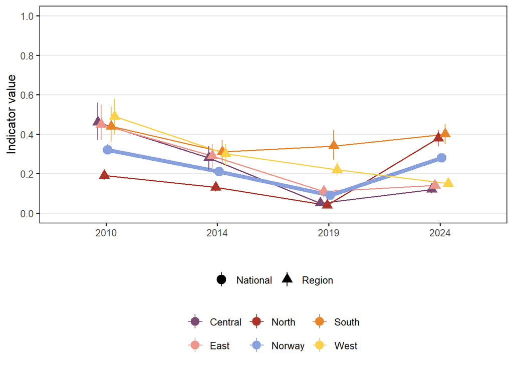

Figure 3: Indicator values for NO_RODE_001 (Rodents) plotted over time and for five different regions, as well as the combined national estimated. The error bars are 95% confidence intervals.

```r
ggplot(plot_data, aes(x = year, y = median, colour = part2, group = part2)) +
  geom_line(
    aes(linewidth = series_type),
    position = position_dodge(width = 0.18)
  ) +
  scale_linewidth_manual(
    values = c(National = 2, Region = 0.55),
    guide = "none"
  ) +
  geom_pointrange(
    aes(ymin = p_025, ymax = p_975, shape = series_type),
    size = 0.8,
    linewidth = 0.45,
    position = position_dodge(width = 0.18)
  ) +
  scale_colour_manual(values = region_cols, name = NULL) +
  scale_shape_manual(
    values = c(National = 19, Region = 17),
    name = NULL
  ) +
  scale_y_continuous(limits = c(0, 1), breaks = seq(0, 1, 0.2)) +
  theme_bw(base_size = 12) +
  theme(
    legend.position = "bottom",
    legend.box = "vertical",
    panel.grid.minor = element_blank(),
    panel.grid.major.x = element_blank()
  ) +
  guides(
    colour = guide_legend(
      nrow = 2,
      override.aes = list(size = 0.7, linewidth = 0.45)
    ),
    shape = guide_legend(override.aes = list(size = 0.8, linewidth = 0.45))
  ) +
  labs(y = "Indicator value", x = "")
```

```r
summary_out |>
  unite(col = "CI_95", c(p_025, p_975), sep = " - ") |>
  unite(col = "IQR", c(p_25, p_75), sep = " - ") |>
  select(
    ECT,
    Indicator,
    ID,
    "Accounting area" = part,
    Ecosystem,
    "Closing year" = year,
    "Indicator value" = median,
    "95% CI" = CI_95,
    "50% CI" = IQR
  ) |>
  knitr::kable()
```

Table 2: Indicator values and uncertainty estimates for NO_RODE_001.

| ECT | Indicator | ID | Accounting area | Ecosystem | Closing year | Indicator value | 95% CI | 50% CI |
| --- | --- | --- | --- | --- | --- | --- | --- | --- |
| B1 | Rodents | NO_RODE_001 | C | Mountains | 2010 | 0.46 | 0.37 - 0.56 | 0.43 - 0.5 |
| B1 | Rodents | NO_RODE_001 | C | Mountains | 2014 | 0.28 | 0.22 - 0.34 | 0.26 - 0.3 |
| B1 | Rodents | NO_RODE_001 | C | Mountains | 2019 | 0.05 | 0.04 - 0.06 | 0.05 - 0.05 |
| B1 | Rodents | NO_RODE_001 | C | Mountains | 2024 | 0.12 | 0.1 - 0.14 | 0.11 - 0.13 |
| B1 | Rodents | NO_RODE_001 | E | Mountains | 2010 | 0.45 | 0.37 - 0.55 | 0.42 - 0.48 |
| B1 | Rodents | NO_RODE_001 | E | Mountains | 2014 | 0.29 | 0.23 - 0.35 | 0.27 - 0.31 |
| B1 | Rodents | NO_RODE_001 | E | Mountains | 2019 | 0.11 | 0.08 - 0.13 | 0.1 - 0.11 |
| B1 | Rodents | NO_RODE_001 | E | Mountains | 2024 | 0.14 | 0.13 - 0.16 | 0.14 - 0.15 |
| B1 | Rodents | NO_RODE_001 | N | Mountains | 2010 | 0.19 | 0.17 - 0.21 | 0.18 - 0.2 |
| B1 | Rodents | NO_RODE_001 | N | Mountains | 2014 | 0.13 | 0.11 - 0.15 | 0.12 - 0.13 |
| B1 | Rodents | NO_RODE_001 | N | Mountains | 2019 | 0.04 | 0.03 - 0.04 | 0.04 - 0.04 |
| B1 | Rodents | NO_RODE_001 | N | Mountains | 2024 | 0.38 | 0.34 - 0.42 | 0.37 - 0.39 |
| B1 | Rodents | NO_RODE_001 | Norway | Mountains | 2010 | 0.32 | 0.3 - 0.35 | 0.32 - 0.33 |
| B1 | Rodents | NO_RODE_001 | Norway | Mountains | 2014 | 0.21 | 0.19 - 0.23 | 0.2 - 0.21 |
| B1 | Rodents | NO_RODE_001 | Norway | Mountains | 2019 | 0.09 | 0.09 - 0.1 | 0.09 - 0.1 |
| B1 | Rodents | NO_RODE_001 | Norway | Mountains | 2024 | 0.28 | 0.26 - 0.3 | 0.27 - 0.29 |
| B1 | Rodents | NO_RODE_001 | S | Mountains | 2010 | 0.44 | 0.36 - 0.54 | 0.41 - 0.48 |
| B1 | Rodents | NO_RODE_001 | S | Mountains | 2014 | 0.31 | 0.25 - 0.37 | 0.28 - 0.33 |
| B1 | Rodents | NO_RODE_001 | S | Mountains | 2019 | 0.34 | 0.27 - 0.42 | 0.32 - 0.37 |
| B1 | Rodents | NO_RODE_001 | S | Mountains | 2024 | 0.40 | 0.35 - 0.45 | 0.38 - 0.42 |
| B1 | Rodents | NO_RODE_001 | W | Mountains | 2010 | 0.49 | 0.4 - 0.58 | 0.46 - 0.52 |
| B1 | Rodents | NO_RODE_001 | W | Mountains | 2014 | 0.30 | 0.24 - 0.35 | 0.28 - 0.32 |
| B1 | Rodents | NO_RODE_001 | W | Mountains | 2019 | 0.22 | 0.19 - 0.26 | 0.21 - 0.24 |
| B1 | Rodents | NO_RODE_001 | W | Mountains | 2024 | 0.15 | 0.13 - 0.16 | 0.14 - 0.15 |

## 11. Export file

The indicator values are exported and can be found under `data/results_NO_RODE_001_v1.0.0.csv`.

**Export data**

```r
write.csv(mc_propagated3, here::here("data/results_NO_RODE_001_v1.0.0.csv"), row.names = F)
```

## 12. Author contributions

Not relevant, as this is the work of a single author. I would, however, like to acknowledge the work of those that created the indicator on *Naturindeks* (Nater and Eriksen 2025).

**Session Info**

This workflow uses `renv`. Run `renv::restore()` to recreate the working environment.